# Entrega 6

Juan Luis Solórzano

2025-04-24

https://github.com/JusSolo/Mineria_Proyecto2.git

# 1. Use los mismos conjuntos de entrenamiento y prueba de las hojas de trabajo pasadas para probar el algoritmo.

```r
y <- datos$SalePrice
set.seed(123)
trainI<- createDataPartition(y, p=0.7, list=FALSE)

train <- datos[trainI, ]
test <- datos[-trainI, ]
```

```r
train$precio_categoria<-cut(train$SalePrice,
                            breaks = c(0, 129975, 214000,Inf),
                            labels = c("Economica", "Intermedia", "Cara" ),
                            include.lowest = TRUE)

test$precio_categoria<-cut(test$SalePrice,
                            breaks = c(0, 129975, 214000, Inf),
                            labels = c("Economica", "Intermedia", "Cara"),
                            include.lowest = TRUE)



x_train <- train[, !(names(train) %in% c("SalePrice", "precio_categoria"))]
y_train <- train$precio_categoria
x_test <- test[, !(names(test) %in% c("SalePrice", "precio_categoria"))]
y_test <- test$precio_categoria
```

# 2. Explore los datos y explique las transformaciones que debe hacerle para generar un modelo de máquinas vectoriales de soporte.

# 3. Use como variable respuesta la variable categórica que especifica si la casa es barata, media o cara

# 4. Genere varios (más de 2) modelos de SVM con diferentes kernels y distintos valores en los parámetros c, gamma (circular) y d (en caso de que utilice el polinomial). Puede tunear el modelo de forma automática siempre que explique los resultados

# 5. Use los modelos para predecir el valor de la variable respuesta

# 6. Haga las matrices de confusión respectivas.

# 7. Analice si los modelos están sobreajustados o desajustados. ¿Qué puede hacer para manejar el sobreajuste o desajuste?

# 8. Compare los resultados obtenidos con los diferentes modelos que hizo en cuanto a efectividad, tiempo de procesamiento y equivocaciones (donde el algoritmo se equivocó más, donde se equivocó menos y la importancia que tienen los errores).

# 9. Compare la eficiencia del mejor modelo de SVM con los resultados obtenidos en los algoritmos de las hojas de trabajo anteriores que usen la misma variable respuesta (árbol de decisión y random forest, naive bayes, KNN, regresión logística). ¿Cuál es mejor para predecir? ¿Cuál se demoró más en procesar?

# 10. Genere un buen modelo de regresión, use para esto la variable del precio de la casa directamente. Tunee el modelo.

# 11. Compare los resultados del modelo de regresión generado con los de hojas anteriores que utilicen la misma variable, como la de regresión lineal, el árbol de regresión, naive bayes, KNN.

# 12. Genere un informe de los resultados y las explicaciones.

## 1. Exploración de los datos

```r
# Asumimos que 'datosC' ya está en el entorno y contiene las variables predictoras y SalePrice
# Recreamos partición de Train/Test igual que en el informe
set.seed(123)
y <- datosC$SalePrice
trainI <- createDataPartition(y, p = 0.7, list = FALSE)
train <- datosC[trainI, ]
test  <- datosC[-trainI, ]

# Creamos la variable respuesta categórica
breaks <- c(0, 129975, 214000, Inf)
labels <- c("Economica","Intermedia","Cara")
train$precio_categoria <- cut(train$SalePrice, breaks = breaks, labels = labels, include.lowest = TRUE)
test$precio_categoria  <- cut(test$SalePrice,  breaks = breaks, labels = labels, include.lowest = TRUE)

# Exploración básica
table(train$precio_categoria)
```

```
##
##  Economica Intermedia       Cara
##        256        514        254
```

```r
prop.table(table(train$precio_categoria))
```

```
##
##  Economica Intermedia       Cara
##  0.2500000  0.5019531  0.2480469
```

```r
summary(train)
```

```
##    SalePrice       LotFrontage        LotArea        OverallQual
##  Min.   : 34900   Min.   :  0.00   Min.   :  1300   Min.   : 1.000
##  1st Qu.:129975   1st Qu.: 42.00   1st Qu.:  7590   1st Qu.: 5.000
##  Median :163000   Median : 63.00   Median :  9410   Median : 6.000
##  Mean   :180841   Mean   : 58.04   Mean   : 10590   Mean   : 6.091
##  3rd Qu.:214000   3rd Qu.: 79.00   3rd Qu.: 11645   3rd Qu.: 7.000
##  Max.   :755000   Max.   :313.00   Max.   :164660   Max.   :10.000
##   OverallCond     YearBuilt     YearRemodAdd    MasVnrArea       BsmtFinSF1
##  Min.   :1.00   Min.   :1872   Min.   :1950   Min.   :   0.0   Min.   :   0.0
##  1st Qu.:5.00   1st Qu.:1954   1st Qu.:1968   1st Qu.:   0.0   1st Qu.:   0.0
##  Median :5.00   Median :1973   Median :1994   Median :   0.0   Median : 381.5
##  Mean   :5.56   Mean   :1971   Mean   :1985   Mean   : 101.1   Mean   : 443.4
##  3rd Qu.:6.00   3rd Qu.:2000   3rd Qu.:2004   3rd Qu.: 168.0   3rd Qu.: 709.0
##  Max.   :9.00   Max.   :2010   Max.   :2010   Max.   :1378.0   Max.   :5644.0
##    BsmtFinSF2        BsmtUnfSF       TotalBsmtSF     X1stFlrSF
##  Min.   :   0.00   Min.   :   0.0   Min.   :   0   Min.   : 334
##  1st Qu.:   0.00   1st Qu.: 220.8   1st Qu.: 793   1st Qu.: 882
##  Median :   0.00   Median : 469.0   Median : 991   Median :1088
##  Mean   :  51.64   Mean   : 565.6   Mean   :1061   Mean   :1170
##  3rd Qu.:   0.00   3rd Qu.: 808.5   3rd Qu.:1302   3rd Qu.:1408
##  Max.   :1474.00   Max.   :2153.0   Max.   :6110   Max.   :4692
##    X2ndFlrSF       LowQualFinSF       GrLivArea     BsmtFullBath
##  Min.   :   0.0   Min.   :  0.000   Min.   : 334   Min.   :0.0000
##  1st Qu.:   0.0   1st Qu.:  0.000   1st Qu.:1136   1st Qu.:0.0000
##  Median :   0.0   Median :  0.000   Median :1465   Median :0.0000
##  Mean   : 340.9   Mean   :  6.738   Mean   :1517   Mean   :0.4277
##  3rd Qu.: 728.0   3rd Qu.:  0.000   3rd Qu.:1772   3rd Qu.:1.0000
##  Max.   :2065.0   Max.   :572.000   Max.   :5642   Max.   :2.0000
##   BsmtHalfBath        FullBath        HalfBath       BedroomAbvGr
##  Min.   :0.00000   Min.   :0.000   Min.   :0.0000   Min.   :0.000
##  1st Qu.:0.00000   1st Qu.:1.000   1st Qu.:0.0000   1st Qu.:2.000
##  Median :0.00000   Median :2.000   Median :0.0000   Median :3.000
##  Mean   :0.05469   Mean   :1.559   Mean   :0.3867   Mean   :2.844
##  3rd Qu.:0.00000   3rd Qu.:2.000   3rd Qu.:1.0000   3rd Qu.:3.000
##  Max.   :2.00000   Max.   :3.000   Max.   :2.0000   Max.   :8.000
##   KitchenAbvGr    TotRmsAbvGrd      Fireplaces     GarageYrBlt
##  Min.   :0.000   Min.   : 2.000   Min.   :0.000   Min.   :1900
##  1st Qu.:1.000   1st Qu.: 5.000   1st Qu.:0.000   1st Qu.:1963
##  Median :1.000   Median : 6.000   Median :1.000   Median :1980
##  Mean   :1.048   Mean   : 6.513   Mean   :0.625   Mean   :1979
```

[output cut: 8 more lines]

```
##  Max.   :4.000   Max.   :1418.0   Max.   :857.00   Max.   :523.00
##  EnclosedPorch      X3SsnPorch      ScreenPorch        PoolArea
##  Min.   :  0.00   Min.   :  0.00   Min.   :  0.00   Min.   :  0.000
##  1st Qu.:  0.00   1st Qu.:  0.00   1st Qu.:  0.00   1st Qu.:  0.000
##  Median :  0.00   Median :  0.00   Median :  0.00   Median :  0.000
##  Mean   : 20.67   Mean   :  2.84   Mean   : 15.14   Mean   :  2.801
##  3rd Qu.:  0.00   3rd Qu.:  0.00   3rd Qu.:  0.00   3rd Qu.:  0.000
##  Max.   :386.00   Max.   :407.00   Max.   :440.00   Max.   :738.000
##     MiscVal             MoSold           YrSold       precio_categoria
##  Min.   :    0.00   Min.   : 1.000   Min.   :2006   Economica :256
##  1st Qu.:    0.00   1st Qu.: 4.000   1st Qu.:2007   Intermedia:514
##  Median :    0.00   Median : 6.000   Median :2008   Cara      :254
##  Mean   :   51.82   Mean   : 6.319   Mean   :2008
##  3rd Qu.:    0.00   3rd Qu.: 8.000   3rd Qu.:2009
##  Max.   :15500.00   Max.   :12.000   Max.   :2010
```

**Observaciones:** - La variable respuesta `precio_categoria` está balanceada en torno a 25–50% por clase. - Existen variables numéricas que requieren centrado y escalado, y posibles valores faltantes.

## 2. Transformaciones necesarias

Para SVM es crucial que las variables numéricas estén normalizadas y no existan NA. Además, convertiremos factores a dummies.

```r
# 1) Eliminación de predictores de varianza casi cero
nzv <- nearZeroVar(train, saveMetrics = TRUE)
train <- train[, !nzv$zeroVar]
test  <- test[, colnames(test) %in% colnames(train)]

# 2) Imputación de valores faltantes + centrado y escalado
pp <- preProcess(train %>% select(-SalePrice, -precio_categoria),
                 method = c("center","scale","knnImpute"))
train_pp <- predict(pp, train)
test_pp  <- predict(pp, test)

# 3) Codificación de factores en dummies para predictores categóricos
dummies <- dummyVars(~ ., data = train_pp %>% select(-SalePrice, -precio_categoria))
train_x <- predict(dummies, newdata = train_pp)
test_x  <- predict(dummies, newdata = test_pp)

# Preparamos data para caret
x_train <- as.data.frame(train_x)
y_train <- train_pp$precio_categoria
x_test  <- as.data.frame(test_x)
y_test  <- test_pp$precio_categoria
```

## 3. Definición de control de entrenamiento

```r
ctrl <- trainControl(method = "repeatedcv", number = 5, repeats = 3,
                     classProbs = TRUE, summaryFunction = multiClassSummary)
```

## 4. Modelos SVM

### 4.1 SVM Lineal

```r
grid_lin <- expand.grid(C = c(0.1, 1, 10))
svm_lin <- train(x_train, y_train, method = "svmLinear",
                 trControl = ctrl, tuneGrid = grid_lin)
svm_lin
```

```
## Support Vector Machines with Linear Kernel
##
## 1024 samples
##   35 predictor
##    3 classes: 'Economica', 'Intermedia', 'Cara'
##
## No pre-processing
## Resampling: Cross-Validated (5 fold, repeated 3 times)
## Summary of sample sizes: 818, 821, 819, 819, 819, 819, ...
## Resampling results across tuning parameters:
##
##   C     logLoss    AUC        prAUC      Accuracy   Kappa      Mean_F1
##    0.1  0.4274141  0.9482423  0.8884803  0.8466445  0.7509514  0.8443582
##    1.0  0.4455822  0.9473231  0.8864311  0.8414285  0.7408239  0.8377079
##   10.0  0.4664172  0.9461297  0.8844024  0.8381939  0.7332534  0.8329701
##   Mean_Sensitivity  Mean_Specificity  Mean_Pos_Pred_Value  Mean_Neg_Pred_Value
##   0.8362863         0.9114446         0.8561436            0.9164732
##   0.8262286         0.9069208         0.8555335            0.9149067
##   0.8163159         0.9027783         0.8614337            0.9150557
##   Mean_Precision  Mean_Recall  Mean_Detection_Rate  Mean_Balanced_Accuracy
##   0.8561436       0.8362863    0.2822148            0.8738654
##   0.8555335       0.8262286    0.2804762            0.8665747
##   0.8614337       0.8163159    0.2793980            0.8595471
##
## Accuracy was used to select the optimal model using the largest value.
## The final value used for the model was C = 0.1.
```

### 4.2 SVM Radial (RBF)

```r
grid_rad <- expand.grid(sigma = c(0.001, 0.01, 0.1), C = c(0.1, 1, 10))
svm_rad <- train(x_train, y_train, method = "svmRadial",
                 trControl = ctrl, tuneGrid = grid_rad)
svm_rad
```

```
## Support Vector Machines with Radial Basis Function Kernel
##
## 1024 samples
##   35 predictor
##    3 classes: 'Economica', 'Intermedia', 'Cara'
##
## No pre-processing
## Resampling: Cross-Validated (5 fold, repeated 3 times)
## Summary of sample sizes: 819, 819, 819, 820, 819, 819, ...
## Resampling results across tuning parameters:
##
##   sigma  C     logLoss    AUC        prAUC      Accuracy   Kappa      Mean_F1
##   0.001   0.1  0.5546005  0.9402993  0.8787211  0.7796430  0.6634994  0.7852081
##   0.001   1.0  0.4338778  0.9430833  0.8836443  0.8196625  0.7116493  0.8198889
##   0.001  10.0  0.4050926  0.9492930  0.8937655  0.8385261  0.7396542  0.8373561
##   0.010   0.1  0.4572172  0.9423134  0.8866822  0.8001279  0.6876875  0.8039683
##   0.010   1.0  0.3814616  0.9512624  0.9011152  0.8346268  0.7336363  0.8332279
##   0.010  10.0  0.3704936  0.9548218  0.9073267  0.8433835  0.7464197  0.8412003
##   0.100   0.1  0.5861882  0.9224454  0.8444093  0.7770254  0.6359824  0.7726574
##   0.100   1.0  0.4640849  0.9365448  0.8720024  0.8115020  0.6877312  0.8043564
##   0.100  10.0  0.4908162  0.9307737  0.8606447  0.7994583  0.6671215  0.7913346
##   Mean_Sensitivity  Mean_Specificity  Mean_Pos_Pred_Value  Mean_Neg_Pred_Value
##   0.8189915         0.8910883         0.7752766            0.8845414
##   0.8211449         0.9003409         0.8217873            0.9001308
##   0.8333548         0.9086425         0.8445294            0.9113104
##   0.8206834         0.8958344         0.7973943            0.8908246
##   0.8305185         0.9068425         0.8391678            0.9090471
##   0.8349799         0.9102960         0.8507995            0.9144289
##   0.7615673         0.8707949         0.7898349            0.8774352
##   0.7848582         0.8863123         0.8370010            0.9004611
##   0.7707599         0.8789249         0.8268624            0.8939269
##   Mean_Precision  Mean_Recall  Mean_Detection_Rate  Mean_Balanced_Accuracy
##   0.7752766       0.8189915    0.2598810            0.8550399
##   0.8217873       0.8211449    0.2732208            0.8607429
##   0.8445294       0.8333548    0.2795087            0.8709986
##   0.7973943       0.8206834    0.2667093            0.8582589
##   0.8391678       0.8305185    0.2782089            0.8686805
##   0.8507995       0.8349799    0.2811278            0.8726379
##   0.7898349       0.7615673    0.2590085            0.8161811
##   0.8370010       0.7848582    0.2705007            0.8355852
##   0.8268624       0.7707599    0.2664861            0.8248424
##
## Accuracy was used to select the optimal model using the largest value.
## The final values used for the model were sigma = 0.01 and C = 10.
```

### 4.3 SVM Polinomial

```r
grid_poly <- expand.grid(degree = c(2, 3, 4), scale = c(0.001, 0.01), C = c(0.1, 1, 10))
svm_poly <- train(x_train, y_train, method = "svmPoly",
                  trControl = ctrl, tuneGrid = grid_poly)
svm_poly
```

```
## Support Vector Machines with Polynomial Kernel
##
## 1024 samples
##   35 predictor
##    3 classes: 'Economica', 'Intermedia', 'Cara'
##
## No pre-processing
## Resampling: Cross-Validated (5 fold, repeated 3 times)
## Summary of sample sizes: 818, 820, 819, 819, 820, 820, ...
## Resampling results across tuning parameters:
##
##   degree  scale  C     logLoss    AUC        prAUC      Accuracy   Kappa
##   2       0.001   0.1  0.5547119  0.9407783  0.8793010  0.7880650  0.6765371
##   2       0.001   1.0  0.4488754  0.9431750  0.8835717  0.8267821  0.7224443
##   2       0.001  10.0  0.4308580  0.9487165  0.8896987  0.8437230  0.7480515
##   2       0.010   0.1  0.4534784  0.9432156  0.8831891  0.8284177  0.7240475
##   2       0.010   1.0  0.4310074  0.9503482  0.8935556  0.8486059  0.7552878
##   2       0.010  10.0  0.4185081  0.9533077  0.8994385  0.8577180  0.7689501
##   3       0.001   0.1  0.5554992  0.9407919  0.8790649  0.7851318  0.6721808
##   3       0.001   1.0  0.4469091  0.9439705  0.8840543  0.8254972  0.7178635
##   3       0.001  10.0  0.4300125  0.9497345  0.8914850  0.8486059  0.7554221
##   3       0.010   0.1  0.4568495  0.9461173  0.8863397  0.8310272  0.7264445
##   3       0.010   1.0  0.4245633  0.9532113  0.8983660  0.8518595  0.7600920
##   3       0.010  10.0  0.4399155  0.9497044  0.8927726  0.8492547  0.7539326
##   4       0.001   0.1  0.5477613  0.9409291  0.8794674  0.7919627  0.6812866
##   4       0.001   1.0  0.4474038  0.9444859  0.8847576  0.8287381  0.7233971
##   4       0.001  10.0  0.4221668  0.9508839  0.8937518  0.8547801  0.7653234
##   4       0.010   0.1  0.4555103  0.9476547  0.8880317  0.8355770  0.7339521
##   4       0.010   1.0  0.4358625  0.9521212  0.8951291  0.8505571  0.7569469
##   4       0.010  10.0  0.4419496  0.9460407  0.8876642  0.8362179  0.7317523
##   Mean_F1    Mean_Sensitivity  Mean_Specificity  Mean_Pos_Pred_Value
##   0.7942952  0.8282762         0.8959976         0.7851914
##   0.8270452  0.8267359         0.9037241         0.8301292
##   0.8426950  0.8384627         0.9115382         0.8491390
##   0.8280667  0.8254009         0.9036446         0.8335407
##   0.8472204  0.8410499         0.9134910         0.8555946
##   0.8556017  0.8471176         0.9174673         0.8675905
##   0.7914854  0.8258732         0.8944699         0.7823350
##   0.8240811  0.8180291         0.9005955         0.8332190
##   0.8472374  0.8418896         0.9137749         0.8550174
```

[output cut: 35 more lines]

```
##   0.8601715
##   0.8593123
##   0.8778323
##   0.8628445
##   0.8790623
##   0.8728536
##   0.8630312
##   0.8624433
##   0.8824263
##   0.8668240
##   0.8757180
##   0.8613346
##
## Accuracy was used to select the optimal model using the largest value.
## The final values used for the model were degree = 2, scale = 0.01 and C = 10.
```

## 5. Resultados de validación interna

```r
resamps <- resamples(list(Linear = svm_lin, Radial = svm_rad, Poly = svm_poly))
summary(resamps)
```

```
##
## Call:
## summary.resamples(object = resamps)
##
## Models: Linear, Radial, Poly
## Number of resamples: 15
##
## Accuracy
##             Min.   1st Qu.    Median      Mean   3rd Qu.      Max. NA's
## Linear 0.8000000 0.8264503 0.8439024 0.8466445 0.8609756 0.9073171    0
## Radial 0.7892157 0.8382353 0.8439024 0.8433835 0.8582018 0.8878049    0
## Poly   0.8097561 0.8414634 0.8536585 0.8577180 0.8777379 0.9024390    0
##
## AUC
##             Min.   1st Qu.    Median      Mean   3rd Qu.      Max. NA's
## Linear 0.9226445 0.9367996 0.9502048 0.9482423 0.9554714 0.9779948    0
## Radial 0.9352301 0.9458199 0.9576355 0.9548218 0.9618873 0.9748196    0
## Poly   0.9317797 0.9411623 0.9545269 0.9533077 0.9631923 0.9724750    0
##
## Kappa
##             Min.   1st Qu.    Median      Mean   3rd Qu.      Max. NA's
## Linear 0.6681800 0.7163890 0.7497520 0.7509514 0.7737344 0.8517094    0
## Radial 0.6573705 0.7357240 0.7502475 0.7464197 0.7687537 0.8225976    0
## Poly   0.6919550 0.7399737 0.7635161 0.7689501 0.8015665 0.8423441    0
##
## logLoss
##             Min.   1st Qu.    Median      Mean   3rd Qu.      Max. NA's
## Linear 0.2965222 0.3848253 0.4375870 0.4274141 0.4663174 0.5343876    0
## Radial 0.3004399 0.3414990 0.3624835 0.3704936 0.4006581 0.4556492    0
## Poly   0.3166981 0.3779270 0.4150660 0.4185081 0.4551655 0.5272742    0
##
## Mean_Balanced_Accuracy
##             Min.   1st Qu.    Median      Mean   3rd Qu.      Max. NA's
## Linear 0.8254386 0.8559607 0.8776574 0.8738654 0.8834855 0.9288786    0
## Radial 0.8267974 0.8621726 0.8776367 0.8726379 0.8813686 0.9202787    0
## Poly   0.8462505 0.8640187 0.8815618 0.8822925 0.8981574 0.9195735    0
##
## Mean_Detection_Rate
##             Min.   1st Qu.    Median      Mean   3rd Qu.     Max. NA's
## Linear 0.2666667 0.2754834 0.2813008 0.2822148 0.2869919 0.302439    0
```

[output cut: 35 more lines]

```
## Linear 0.7716226 0.8130719 0.8401548 0.8362863 0.8486385 0.9088140    0
## Radial 0.7745098 0.8199251 0.8415387 0.8349799 0.8462295 0.8991687    0
## Poly   0.8011930 0.8230605 0.8468177 0.8471176 0.8672949 0.8956787    0
##
## Mean_Specificity
##             Min.   1st Qu.    Median      Mean   3rd Qu.      Max. NA's
## Linear 0.8792547 0.8988494 0.9130804 0.9114446 0.9184276 0.9489432    0
## Radial 0.8790850 0.9044201 0.9137347 0.9102960 0.9165078 0.9413887    0
## Poly   0.8913080 0.9052097 0.9163059 0.9174673 0.9290199 0.9434683    0
##
## prAUC
##             Min.   1st Qu.    Median      Mean   3rd Qu.      Max. NA's
## Linear 0.8417757 0.8771483 0.8859864 0.8884803 0.8949178 0.9461024    0
## Radial 0.8776792 0.8909032 0.9149708 0.9073267 0.9194443 0.9393819    0
## Poly   0.8551793 0.8801221 0.9044741 0.8994385 0.9153282 0.9349073    0
```

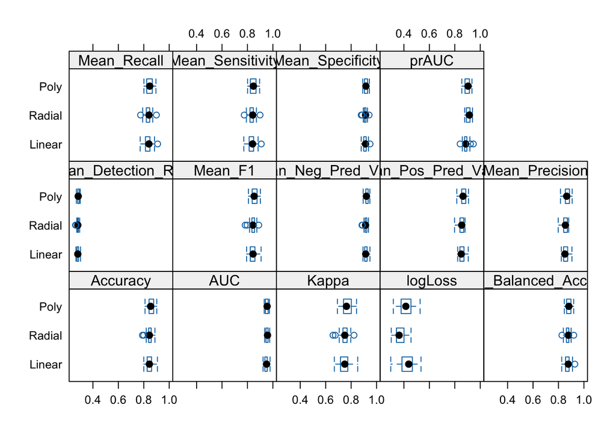

```r
bwplot(resamps)
```